← All notes Source: `14_augment_explained.ipynb`

Get the notebook ↓ Download .ipynb [▶ Open in Colab](https://colab.research.google.com/github/shammun/shammunul-fastai-notes/blob/main/notebooks/14_augment_explained_colab.ipynb)

# Data Augmentation - Explained

## What This Notebook Covers

This notebook explores **data augmentation** - techniques to artificially expand your training dataset by applying transformations to existing images. Augmentation is one of the most effective ways to improve model generalization.

### Why Data Augmentation?

| Problem | Without Augmentation | With Augmentation |
| --- | --- | --- |
| **Overfitting** | Model memorizes training data | Model learns general patterns |
| **Limited data** | Need more images | Artificially expand dataset |
| **Position invariance** | Model fails on shifted images | Model handles variations |

### Example: Training vs Validation Gap

Without augmentation after 20 epochs:

```
Training accuracy:   99.9%
Validation accuracy: 92.4%  ← Big gap = overfitting!
```

### Augmentation Techniques We'll Cover

1. **Going Wider** - Wider ResNet models
2. **Global Average Pooling** - Reduce parameters
3. **Basic Augmentation** - RandomCrop, RandomHorizontalFlip
4. **Test Time Augmentation (TTA)** - Augment at inference
5. **Random Erase** - Randomly erase parts of image
6. **Random Copy** - Copy patches within image
7. **Dropout** - Randomly zero activations

Let's dive in!

## Part 1: Setup and Imports

```python
#|default_exp augment
# This cell marks that code with #|export will be exported to miniai/augment.py
```

```python
#|export
import torch, random
import fastcore.all as fc

from torch import nn
from torch.nn import init

# Our custom modules from previous notebooks
from miniai.datasets import *
from miniai.conv import *
from miniai.learner import *
from miniai.activations import *
from miniai.init import *
from miniai.sgd import *
from miniai.resnet import *
```

```python
# Standard imports
import pickle, gzip, math, os, time, shutil
import matplotlib as mpl, numpy as np, matplotlib.pyplot as plt
from collections.abc import Mapping
from pathlib import Path
from operator import attrgetter, itemgetter
from functools import partial
from copy import copy
from contextlib import contextmanager

# PyTorch imports
import torchvision.transforms.functional as TF
import torch.nn.functional as F
from torch import tensor, optim
from torch.utils.data import DataLoader, default_collate
from torch.optim import lr_scheduler
from torcheval.metrics import MulticlassAccuracy
from datasets import load_dataset, load_dataset_builder

from fastcore.test import test_close
from torch import distributions  # For dropout implementation

# Configure display
torch.set_printoptions(precision=2, linewidth=140, sci_mode=False)
torch.manual_seed(1)
mpl.rcParams['image.cmap'] = 'gray'
```

```python
# ============================================================================
# INTERACTIVE VISUALIZATIONS -- setup (run this cell ONCE).
# Each "🎮 Interactive" cell below loads a standalone HTML file from the
# published copy on GitHub Pages, in an isolated <iframe> (its CSS/JS can't leak
# into the notebook). It is shown FULL WIDTH and auto-fits its content height.
# No local files needed -- the visualizations are read from GitHub.
# ============================================================================
from IPython.display import HTML

def show_viz(path, height="600px"):
    """Embed an interactive visualization full width; it auto-fits its height.
    `path` may be a bare 'interactive_viz/<file>.html' (resolved to the GitHub
    Pages copy) or a full https URL."""
    base = "https://shammun.github.io/shammunul-fastai-notes/notebooks/"
    if not path.startswith("http"):
        path = base + path
    return HTML(
        f'<iframe src="{path}" loading="lazy" allowfullscreen '
        f'style="width:100%;height:{height};border:1px solid #dde5f2;border-radius:12px;'
        f'box-shadow:0 8px 24px rgba(123,92,214,.12);background:#fff;"></iframe>'
        '<script>addEventListener("message",function(e){'
        'if(e.data&&e.data.type==="ce-frame-height"&&e.data.height>50){'
        'var fs=document.querySelectorAll("iframe");for(var i=0;i<fs.length;i++){'
        'if(fs[i].contentWindow===e.source){fs[i].style.height=e.data.height+"px";break;}}}});</script>'
    )
```

## Part 2: Data Setup

```python
# Dataset configuration
xl, yl = 'image', 'label'
name = "zalando-datasets/fashion_mnist"
bs = 1024
xmean, xstd = 0.28, 0.35  # Normalization constants

# Transform: normalize images
@inplace
def transformi(b):
    b[xl] = [(TF.to_tensor(o) - xmean) / xstd for o in b[xl]]

# Load dataset
dsd = load_dataset(name)
tds = dsd.with_transform(transformi)
dls = DataLoaders.from_dd(tds, bs, num_workers=fc.defaults.cpus)
```

```python
# Setup callbacks and model configuration
metrics = MetricsCB(accuracy=MulticlassAccuracy())
astats = ActivationStats(fc.risinstance(GeneralRelu))
cbs = [DeviceCB(), metrics, ProgressCB(plot=True), astats]

# GeneralRelu activation
act_gr = partial(GeneralRelu, leak=0.1, sub=0.4)

# Kaiming initialization
iw = partial(init_weights, leaky=0.1)
```

```python
# Training configuration
set_seed(42)
lr, epochs = 6e-2, 5
```

## Part 3: Going Wider

Before we explore augmentation, let's try making our model wider (more channels per layer).

```python
def get_model(act=nn.ReLU, nfs=(16, 32, 64, 128, 256, 512), norm=nn.BatchNorm2d):
    """
    Create a wider ResNet model.

    Note: This version uses more channels (16→512 vs 8→256 before).
    The first layer uses a 5x5 kernel for better feature capture.

    Args:
        act: Activation function class
        nfs: Tuple of filter counts (default: wider than before)
        norm: Normalization layer class

    Returns:
        nn.Sequential model
    """
    # First ResBlock with 5x5 kernel (larger receptive field)
    layers = [ResBlock(1, 16, ks=5, stride=1, act=act, norm=norm)]

    # Add ResBlocks with stride=2 (halving spatial dimensions)
    layers += [ResBlock(nfs[i], nfs[i+1], act=act, norm=norm, stride=2)
               for i in range(len(nfs)-1)]

    # Classification head
    layers += [nn.Flatten(), nn.Linear(nfs[-1], 10, bias=False), nn.BatchNorm1d(10)]

    return nn.Sequential(*layers)
```

```python
# Train wider model
lr = 1e-2
tmax = epochs * len(dls.train)
sched = partial(lr_scheduler.OneCycleLR, max_lr=lr, total_steps=tmax)
xtra = [BatchSchedCB(sched)]

model = get_model(act_gr, norm=nn.BatchNorm2d).apply(iw)
learn = TrainLearner(model, dls, F.cross_entropy, lr=lr, cbs=cbs+xtra, opt_func=optim.AdamW)
```

| accuracy | loss | epoch | train |
| --- | --- | --- | --- |
| 0.824 | 0.704 | 0 | train |
| 0.854 | 0.593 | 0 | eval |
| 0.899 | 0.381 | 1 | train |
| 0.889 | 0.369 | 1 | eval |
| 0.921 | 0.267 | 2 | train |
| 0.908 | 0.287 | 2 | eval |
| 0.941 | 0.197 | 3 | train |
| 0.927 | 0.235 | 3 | eval |
| 0.962 | 0.139 | 4 | train |
| 0.930 | 0.224 | 4 | eval |

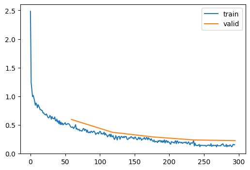

```python
learn.fit(epochs)
```

## Part 4: Global Average Pooling

Instead of flattening the final feature map directly, we can use **Global Average Pooling (GAP)** to reduce each channel to a single value.

```python
class GlobalAvgPool(nn.Module):
    """
    Global Average Pooling.

    Takes the mean across spatial dimensions (height and width),
    reducing each channel to a single value.

    Input:  (batch, channels, height, width)
    Output: (batch, channels)

    Benefits:
    - Reduces parameters (no flattening of spatial dims)
    - Works with any input size
    - Acts as structural regularization
    """
    def forward(self, x):
        # Take mean over last two dimensions (height, width)
        # (-2, -1) means second-to-last and last dimensions
        return x.mean((-2, -1))
```